# Cointegration and the Two-Step Method

Roo Fernando

2023-04-08

### Stationarity and why we would want it?

Time-series data can be all over the place. What we are searching for are some descriptive statistical characteristics which allow us to describe the time-series in a useful way. When able to describe the time-series we are more confident in applying inferential statistics (making predictions). When we say a time-series is stationary we are saying that over time that certain statistical characteristics are constant. For our application we are using a weakly stationary process rather than strictly stationary. The difference is that a strictly stationary process has equivalent characteristics for its distribution throughout while a weakly stationary process has equivalance in mean, variance, and covariances. It’s just a more practical approach to real world data.

#### Weakly stationary process

We define $Y = {Y_t}$ to be a stochastic process. The process is stationary if the below criteria are satisfied.

1. $E[Y_t] = \mu < \inf$
2. $Cov(Y_t, Y_{t-h}) = \gamma(h) < \inf$

The time series has to have a constant $\mu$ and when selecting a range h for the time-series the covariance should be constant, and as you shift around the time-series with that same h the covariance should remain the same.

### Cointegration

When looking at stocks it’s easy to see that it is not stationary.

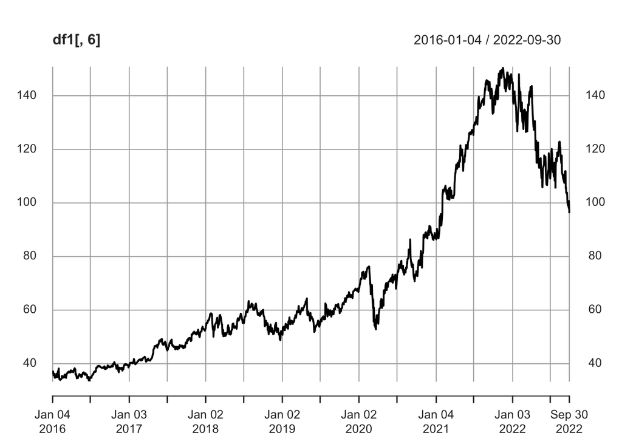

```r
library(quantmod)
df1 <- getSymbols("GOOG", from="2016-01-03", to="2022-10-01", env=NULL, timeout=30)
plot(df1[,6])
```

There is a clear trend upward, meaning no constant $\mu \text{ or } \gamma(h)$. So applying any type of forecast utilizing a stationary process would not work. Knowing that stocks are not stationary a work around can be to search for a stationary process which are made up of two non-stationary processes. This new stationary process is called cointegration. We are going to utilize the two-step method to find a cointegration relationship between pairs of assets.

The two-step method fits a linear regression model of two assets with one asset being the response variable and the other being the predictor, and tests that the residuals of that model are stationary. The test’s we will utilize are the Phillips-Ouliaris cointegration test and the KPSS test.

### Experiment

The code below searches through the S&P500 for a combination of two assets that are cointegrated. It will iterate over 120,000 combinations in this case searching for a cointegrated process (consisting of two assets) that pass the Phillips-Ouliaris cointegration test and KPSS test.

```r
library(quantmod)
library(forecast)
library(urca)
library(tseries)
library(BatchGetSymbols)

set.seed(100)
start <- "2016-01-03"
end <- "2022-10-01"
df <- data.frame(ticker1 = character(),
                 ticker2 = character(),
                 kpss = numeric(),
                 one_pct = numeric(),
                 P = numeric(),
                 rank = numeric())

sp500 <- GetSP500Stocks()
for (i in 1:length(sp500$Tickers)){
  ticker1 <- sp500$Tickers[i]
  x1 <- tryCatch(
    {
      df1 <- getSymbols(c(ticker1), from=start, to=end, env=NULL, timeout=30)
    },
    error = function(e) {
      print('error with ticker')
    }
  )
  if (length(x1)>2){

  }
  else{
    Sys.sleep(1)
    next
  }
  for (j in (i+1):length(sp500$Tickers)){
    cat(ticker1, sp500$Tickers[j],"\n")
    ticker2 <- sp500$Tickers[j]

    x2 <- tryCatch(
      {
        df2 <- getSymbols(c(ticker2), from=start, to=end, env=NULL, timeout=30)
      },
      error = function(e) {
        print('error with ticker')
      }
    )
    if (length(x2)>2){
      #setup dataframe of logprices for both tickers
      prices <- na.omit(merge(df1[,6],df2[,6]))
      #plot(log.prices, legend.loc="top", main ="Log prices")
      names(prices) <- c(ticker1, ticker2)
      #fit a linear regression for our given ticker to iterated ticker
      fit <- lm(prices[,1]~prices[,2])

      cc <- coefficients(fit)[[2]]
      #define our new Z function which is our cointegration
      z <- as.numeric(prices[,1] - cc*prices[,2])

      #extract our Philips Olarius and 1pct critical val
      coint.po <- ca.po(prices, demean="constant")
      wow <- summary(coint.po)
      one_pct <- wow@cval[3]
      P <- wow@teststat
      value <- kpss.test(z)
      kpss <- value$p.value

      if((P > one_pct)&(kpss >= 0.1)){
        cat(P, one_pct, kpss, "\n")
        rank <- P-one_pct
        df[nrow(df) + 1,] <- c(ticker1=as.character(ticker1),ticker2=as.character(ticker2),
                               kpss = as.numeric(kpss),
                               one_pct=as.numeric(one_pct),
                               P=as.numeric(P), Rank=as.numeric(rank))

      }
    }
    else{
      Sys.sleep(1)
      next
    }
  }
}
write.csv(df, "sp500_project.csv", row.names = FALSE)
```

### Results

For this particular run we find the results below.

| ticker1 | ticker2 | kpss | one_pct | P | rank |
| --- | --- | --- | --- | --- | --- |
| ABT | CARR | 0.1 | 48.0021 | 52.27846 | 4.276361 |
| HD | LIN | 0.1 | 48.0021 | 75.24260 | 27.240505 |
| HD | RMD | 0.1 | 48.0021 | 51.73153 | 3.729431 |

Out of over 120,000 combinations only 3 have met the metric. Since data used was through October of 2022 we can output the plots and see how well it did as we go through April of 2023.

```r
library(quantmod)
library(forecast)
library(urca)
library(tseries)
library(BatchGetSymbols)
```

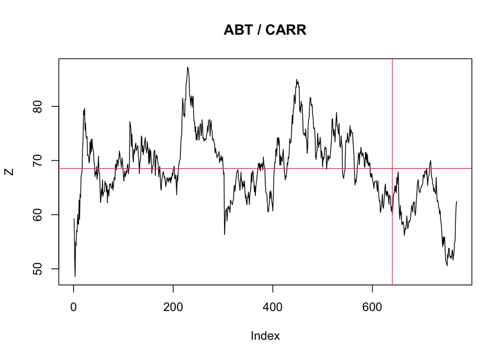

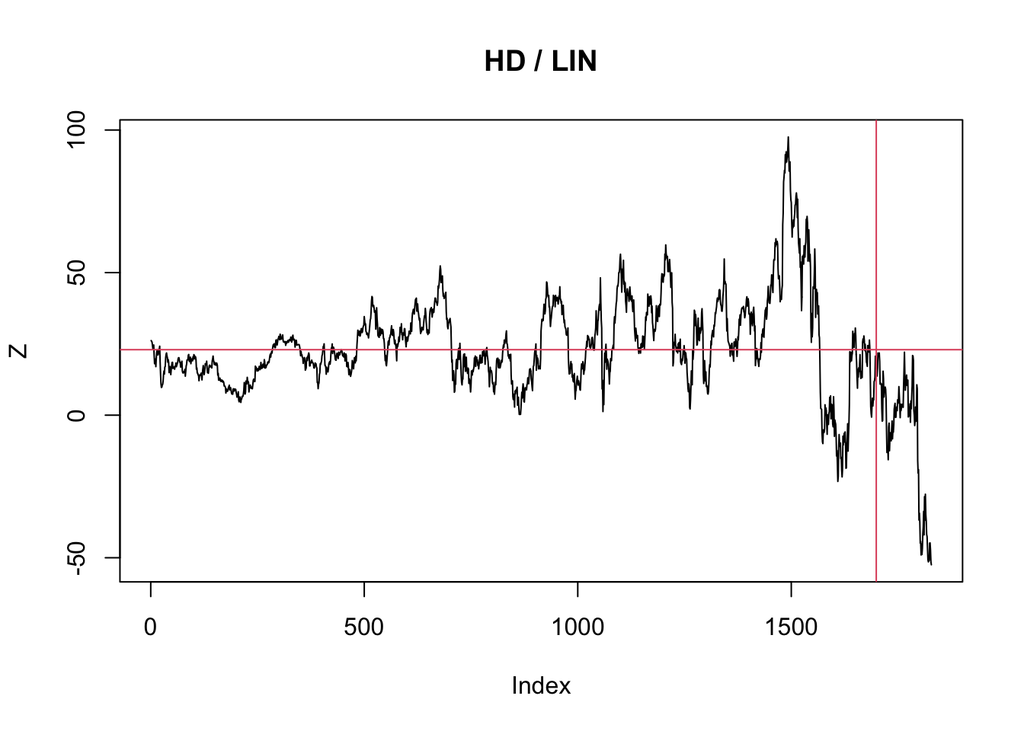

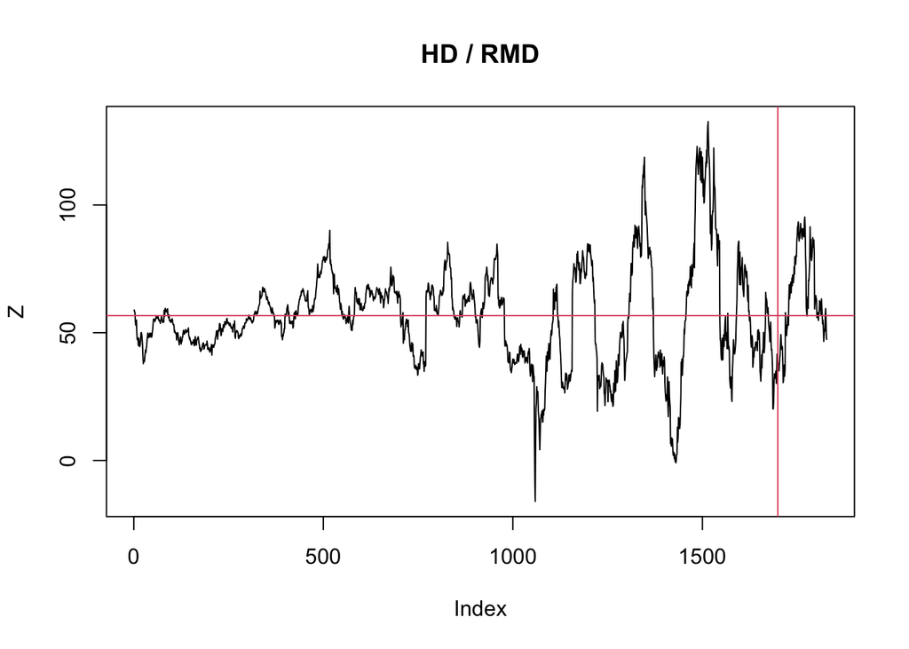

```r
combinations <- data.frame(ticker1 = c("ABT", "HD", "HD"),
                 ticker2 = c("CARR", "LIN", "RMD"))
start <- "2016-01-03"
end <- "2023-10-01"

for (i in 1:length(combinations[,1])){
ticker1 <- combinations[i,1]
ticker2 <- combinations[i,2]

df1 <- getSymbols(c(ticker1), from=start, to=end, env=NULL, timeout=30)
df2 <- getSymbols(c(ticker2), from=start, to=end, env=NULL, timeout=30)

prices <- na.omit(merge(df1[,6],df2[,6]))
#plot(log.prices, legend.loc="top", main ="Log prices")
names(prices) <- c(ticker1, ticker2)
#fit a linear regression for our given ticker to iterated ticker
fit <- lm(prices[,1]~prices[,2])
cc <- coefficients(fit)[[2]]
z <- as.numeric(prices[,1] - cc*prices[,2])
plot(as.numeric(prices[,1] - cc*prices[,2]), type="l", ylab="Z", main=paste(ticker1,"/",ticker2))
#our intercept from our linear regression model
abline(h = coefficients(fit)[[1]], col=2)
if (i==1){
  abline(v=640, col=2)
}
else{
abline(v=1699, col=2)
}
}
```